# Predicting the quality of exercise performance based on data from wearable devices

Marguerite Smith

23 March 2017

## Executive summary

*Scope and Objective:* This project presents a model for predicting whether or not an exercise has been done correctly, based on the work and dataset provided by Velloso et al. (2013).

A comparison has been done of several models, and accuracy calculated for each. In the end, the best model was the random forest, with an accuracy of over 99%.

## Data loading and examination

We begin by loading the data from the Practical Machine Learning data repository hosted by Cloudfront.

```r
# This reads the training data file directly from the repository into a local variable.
#train_data <- read.csv(url("https://d396qusza40orc.cloudfront.net/predmachlearn/pml-training.csv"), header=TRUE)

# Do the same for the testing data, which will be used later.
#test_data <- read.csv(url("https://d396qusza40orc.cloudfront.net/predmachlearn/pml-testing.csv"), header=TRUE)

# download.file("https://d396qusza40orc.cloudfront.net/predmachlearn/pml-training.csv", 'pml-training.csv',quiet=TRUE)
# download.file("https://d396qusza40orc.cloudfront.net/predmachlearn/pml-testing.csv", 'pml-testing.csv',quiet=TRUE)
#
train_data <- read.csv('pml-training.csv')
test_data <- read.csv('pml-testing.csv')
```

Now that we have the data, we must do an initial examination and perform any necessary tidying.

```r
dim(train_data)
```

```
## [1] 19622   160
```

```r
dim(test_data)
```

```
## [1]  20 160
```

From this, we can see that we have a relatively robust training set of 19,622 entries on 160 different variables. The test set is much smaller, with only 20 entries. Note that the test set is reserved for use in the quiz portion of this assignment, so we will still have to partition the training set into further divisions.

## Data cleaning

Next, we take a quick look at the training data to see what, if any, tidying is needed.

```r
str(train_data)
```

```
## 'data.frame':    19622 obs. of  160 variables:
##  $ X                       : int  1 2 3 4 5 6 7 8 9 10 ...
##  $ user_name               : Factor w/ 6 levels "adelmo","carlitos",..: 2 2 2 2 2 2 2 2 2 2 ...
##  $ raw_timestamp_part_1    : int  1323084231 1323084231 1323084231 1323084232 1323084232 1323084232 1323084232 1323084232 1323084232 1323084232 ...
##  $ raw_timestamp_part_2    : int  788290 808298 820366 120339 196328 304277 368296 440390 484323 484434 ...
##  $ cvtd_timestamp          : Factor w/ 20 levels "02/12/2011 13:32",..: 9 9 9 9 9 9 9 9 9 9 ...
##  $ new_window              : Factor w/ 2 levels "no","yes": 1 1 1 1 1 1 1 1 1 1 ...
##  $ num_window              : int  11 11 11 12 12 12 12 12 12 12 ...
##  $ roll_belt               : num  1.41 1.41 1.42 1.48 1.48 1.45 1.42 1.42 1.43 1.45 ...
##  $ pitch_belt              : num  8.07 8.07 8.07 8.05 8.07 8.06 8.09 8.13 8.16 8.17 ...
##  $ yaw_belt                : num  -94.4 -94.4 -94.4 -94.4 -94.4 -94.4 -94.4 -94.4 -94.4 -94.4 ...
##  $ total_accel_belt        : int  3 3 3 3 3 3 3 3 3 3 ...
##  $ kurtosis_roll_belt      : Factor w/ 397 levels "","-0.016850",..: 1 1 1 1 1 1 1 1 1 1 ...
##  $ kurtosis_picth_belt     : Factor w/ 317 levels "","-0.021887",..: 1 1 1 1 1 1 1 1 1 1 ...
##  $ kurtosis_yaw_belt       : Factor w/ 2 levels "","#DIV/0!": 1 1 1 1 1 1 1 1 1 1 ...
```

[output cut: 86 more lines]

Several of the observations seem to be predominantly ‘NA’, and many are also blank. As a subjective measure, we will exclude any observation that is more than 85% NA or blank, as these will not provide quality information and may, in fact, distort the models.

In addition, we can see that the first 7 columns are unrelated to the actual physical movements. Although it is possible that time of day might have an impact on exercise execution, for this project we are focusing solely on the physical movements.

First, strip the first seven columns from the data. Next, remove any columns whose values are 85% or more NA or blank.

```r
# Simple first - just take away the first 7 columns.
clean_train <- train_data[, -c(1:7)]

# Now check each column and count each time an entry is NA OR blank.
# If that number is greater than 85% of nrow(train_data), take it out.
sum_blanks <- colSums(is.na(clean_train) | clean_train=="")
threshold <- .85 * nrow(clean_train)
remove_these <- which(sum_blanks > threshold)
clean_train <- clean_train[, -remove_these]
# dim(clean_train)
```

Now we are dealing with only 53 columns of data, rather than the original 160. Perform the same cleaning on the test data.

```r
# Simple first - just take away the first 7 columns.
clean_test <- test_data[, -c(1:7)]

# Reuse the same removed columns as above. Don't recalculate.
clean_test <- clean_test[, -remove_these]
# dim(clean_test)
```

## Training and test set creation

As mentioned above, the file $pml-testing.csv$ will actually be used for a separate validation exercise, so we must create our own training and testing subdivisions of the $pml-training.csv$ set.

```r
# Take 80% of the set to use as our training subset, and leave 20% for testing. Remember that 'classe' is our outcome variable. Keep the results as a matrix.
# Be sure to set a seed for reproducability.
set.seed(4747)
emargsm_intrain <- createDataPartition(clean_train$classe, p=0.8, list=FALSE)
emargsm_training <- clean_train[emargsm_intrain,]
emargsm_testing <- clean_train[-emargsm_intrain,]
```

## Initial modelling

Now that we have our cleaned data sets, we can begin our modelling.

We will compare three different types of models covered in the PML course: random forest, gradient boosting, and classification tree. As also discussed in PML, we’ll use k-fold cross-validation to improve our model evaluation. To do this, we will take advantage of the parameter `trControl = trainControl()` within `caret::train()`.

```r
# By default, trainControl() uses the "boot" method.
# When we switch it to "cv" for cross-validation, the default
# number of folds is 10 and the number of repeats is 1.
# Note that 10 folds are incredibly computationally intensive.
# (As an example, RF processing time is > 1 hr on this laptop.)
# 10-fold accuracy: 0.9939
# 5-fold accuracy: 0.9929
# For no significant difference in the output and half the processing
# time, use 5-fold CV.
TC <- trainControl(method = "cv", number = 5)
```

### Random forest

We build a random forest model on our training subset and then predict against our testing subset. Use a confusion matrix to compare our prediction to the actual outcomes.

```r
RFmod <- train(classe ~ ., method = "rf", data = emargsm_training, trControl = TC)
```

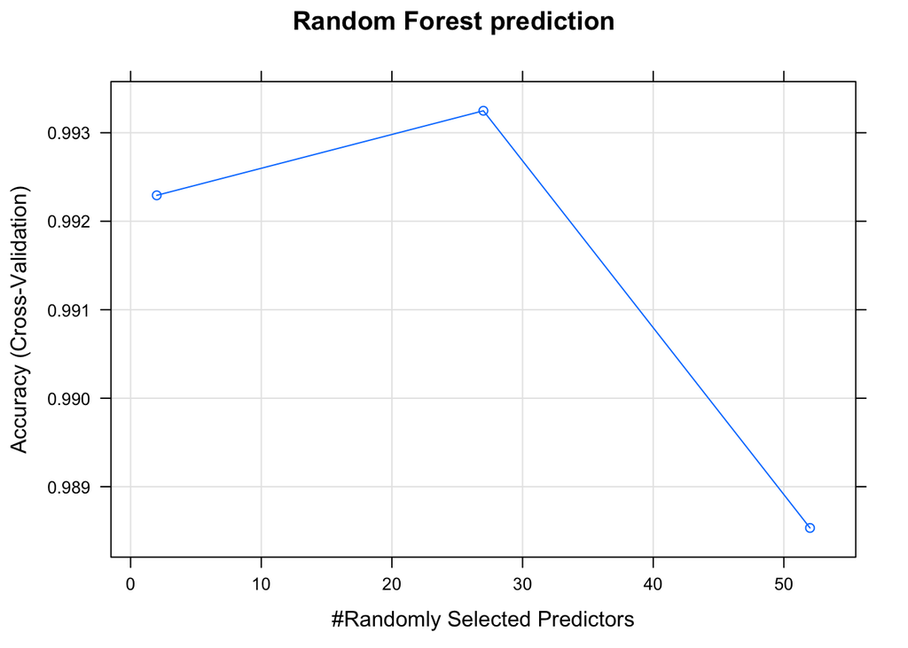

```r
RFpredict <- predict(RFmod,emargsm_testing)

RF_output <- confusionMatrix(RFpredict, emargsm_testing$classe)
plot(RFmod, main="Random Forest prediction")
```

```r
print(RFmod)
```

```
## Random Forest
##
## 15699 samples
##    52 predictor
##     5 classes: 'A', 'B', 'C', 'D', 'E'
##
## No pre-processing
## Resampling: Cross-Validated (5 fold)
## Summary of sample sizes: 12559, 12558, 12561, 12560, 12558
## Resampling results across tuning parameters:
##
##   mtry  Accuracy   Kappa
##    2    0.9922926  0.9902494
##   27    0.9932482  0.9914590
##   52    0.9885338  0.9854942
##
## Accuracy was used to select the optimal model using  the largest value.
## The final value used for the model was mtry = 27.
```

```r
print(RF_output)
```

```
## Confusion Matrix and Statistics
##
##           Reference
## Prediction    A    B    C    D    E
##          A 1114   10    0    0    0
##          B    1  749    0    1    0
##          C    1    0  681   10    1
##          D    0    0    3  632    1
##          E    0    0    0    0  719
##
## Overall Statistics
##
##                Accuracy : 0.9929
##                  95% CI : (0.9897, 0.9953)
##     No Information Rate : 0.2845
##     P-Value [Acc > NIR] : < 2.2e-16
##
##                   Kappa : 0.991
##  Mcnemar's Test P-Value : NA
##
## Statistics by Class:
##
##                      Class: A Class: B Class: C Class: D Class: E
## Sensitivity            0.9982   0.9868   0.9956   0.9829   0.9972
## Specificity            0.9964   0.9994   0.9963   0.9988   1.0000
## Pos Pred Value         0.9911   0.9973   0.9827   0.9937   1.0000
## Neg Pred Value         0.9993   0.9968   0.9991   0.9967   0.9994
## Prevalence             0.2845   0.1935   0.1744   0.1639   0.1838
## Detection Rate         0.2840   0.1909   0.1736   0.1611   0.1833
## Detection Prevalence   0.2865   0.1914   0.1767   0.1621   0.1833
## Balanced Accuracy      0.9973   0.9931   0.9960   0.9908   0.9986
```

### Gradient boosting

Next comes gradient boosting. Repeat the same steps as above.

```r
GBMmod <- train(classe ~ ., method = "gbm", data = emargsm_training, trControl = TC, verbose = FALSE)
GBMpredict <- predict(GBMmod,emargsm_testing)

GBM_output <- confusionMatrix(GBMpredict, emargsm_testing$classe)
print(GBM_output)
```

```
## Confusion Matrix and Statistics
##
##           Reference
## Prediction    A    B    C    D    E
##          A 1103   26    0    0    1
##          B    8  717   19    3   11
##          C    4   13  654   31    4
##          D    0    2    8  606   11
##          E    1    1    3    3  694
##
## Overall Statistics
##
##                Accuracy : 0.962
##                  95% CI : (0.9556, 0.9678)
##     No Information Rate : 0.2845
##     P-Value [Acc > NIR] : < 2.2e-16
##
##                   Kappa : 0.9519
##  Mcnemar's Test P-Value : NA
##
## Statistics by Class:
##
##                      Class: A Class: B Class: C Class: D Class: E
## Sensitivity            0.9884   0.9447   0.9561   0.9425   0.9626
## Specificity            0.9904   0.9870   0.9839   0.9936   0.9975
## Pos Pred Value         0.9761   0.9459   0.9263   0.9665   0.9886
## Neg Pred Value         0.9953   0.9867   0.9907   0.9888   0.9916
## Prevalence             0.2845   0.1935   0.1744   0.1639   0.1838
## Detection Rate         0.2812   0.1828   0.1667   0.1545   0.1769
## Detection Prevalence   0.2880   0.1932   0.1800   0.1598   0.1789
## Balanced Accuracy      0.9894   0.9659   0.9700   0.9680   0.9800
```

[figure not shown]

```r
plot(GBMmod, main="Random Forest prediction")
```

```r
print(GBMmod)
```

```
## Stochastic Gradient Boosting
##
## 15699 samples
##    52 predictor
##     5 classes: 'A', 'B', 'C', 'D', 'E'
##
## No pre-processing
## Resampling: Cross-Validated (5 fold)
## Summary of sample sizes: 12561, 12559, 12560, 12558, 12558
## Resampling results across tuning parameters:
##
##   interaction.depth  n.trees  Accuracy   Kappa
##   1                   50      0.7517052  0.6850988
##   1                  100      0.8229192  0.7758293
##   1                  150      0.8538130  0.8149858
##   2                   50      0.8541310  0.8151881
##   2                  100      0.9062990  0.8814236
##   2                  150      0.9296128  0.9109215
##   3                   50      0.8964892  0.8689843
##   3                  100      0.9415874  0.9260811
##   3                  150      0.9613339  0.9510856
##
## Tuning parameter 'shrinkage' was held constant at a value of 0.1
##
## Tuning parameter 'n.minobsinnode' was held constant at a value of 10
## Accuracy was used to select the optimal model using  the largest value.
## The final values used for the model were n.trees = 150,
##  interaction.depth = 3, shrinkage = 0.1 and n.minobsinnode = 10.
```

```r
print(GBM_output)
```

```
## Confusion Matrix and Statistics
##
##           Reference
## Prediction    A    B    C    D    E
##          A 1103   26    0    0    1
##          B    8  717   19    3   11
##          C    4   13  654   31    4
##          D    0    2    8  606   11
##          E    1    1    3    3  694
##
## Overall Statistics
##
##                Accuracy : 0.962
##                  95% CI : (0.9556, 0.9678)
##     No Information Rate : 0.2845
##     P-Value [Acc > NIR] : < 2.2e-16
##
##                   Kappa : 0.9519
##  Mcnemar's Test P-Value : NA
##
## Statistics by Class:
##
##                      Class: A Class: B Class: C Class: D Class: E
## Sensitivity            0.9884   0.9447   0.9561   0.9425   0.9626
## Specificity            0.9904   0.9870   0.9839   0.9936   0.9975
## Pos Pred Value         0.9761   0.9459   0.9263   0.9665   0.9886
## Neg Pred Value         0.9953   0.9867   0.9907   0.9888   0.9916
## Prevalence             0.2845   0.1935   0.1744   0.1639   0.1838
## Detection Rate         0.2812   0.1828   0.1667   0.1545   0.1769
## Detection Prevalence   0.2880   0.1932   0.1800   0.1598   0.1789
## Balanced Accuracy      0.9894   0.9659   0.9700   0.9680   0.9800
```

Accuracy in this case is 0.9620189. It is still very good, but not as accurate as random forest modeling. On the other hand, if computation time is an issue, this may be the better choice: This takes 10 minutes to perform, compared to nearly 35 minutes.

### Classification tree

Finally, repeat the steps with a classification tree.

```r
CTmod <- train(classe ~ ., method = "rpart", data = emargsm_training, trControl = TC)
```

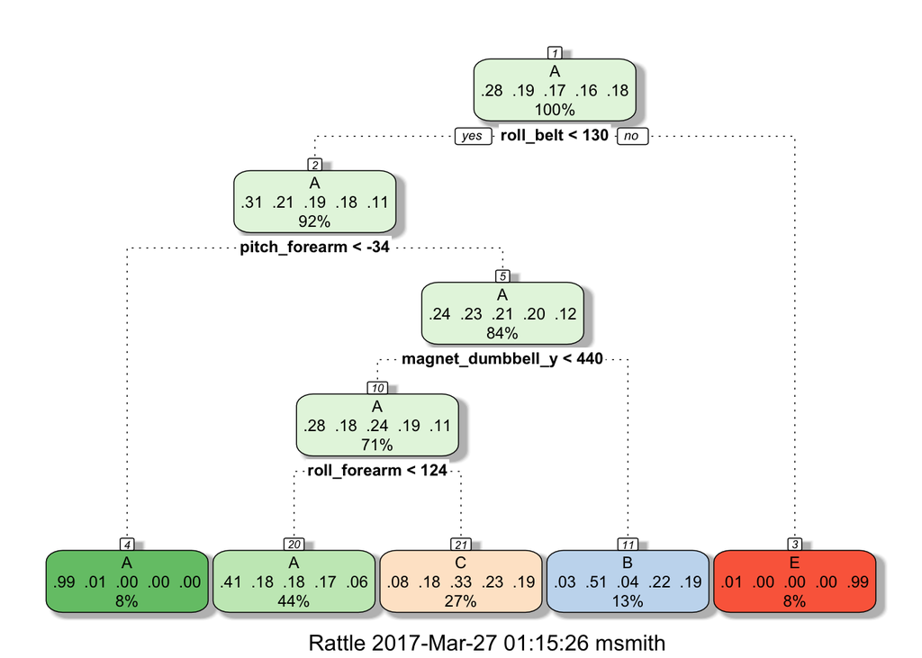

```r
CTpredict <- predict(CTmod, emargsm_testing)

CT_output <- confusionMatrix(CTpredict, emargsm_testing$classe)
# plot(CTmod)
# Instead of using the basic plot, use the fancy tree plot shown
# in this week's lectures.
fancyRpartPlot(CTmod$finalModel)
```

```r
print(CTmod)
```

```
## CART
##
## 15699 samples
##    52 predictor
##     5 classes: 'A', 'B', 'C', 'D', 'E'
##
## No pre-processing
## Resampling: Cross-Validated (5 fold)
## Summary of sample sizes: 12559, 12558, 12560, 12560, 12559
## Resampling results across tuning parameters:
##
##   cp          Accuracy   Kappa
##   0.03569203  0.5069749  0.35954201
##   0.05999110  0.4165283  0.20863434
##   0.11490877  0.3316105  0.07206382
##
## Accuracy was used to select the optimal model using  the largest value.
## The final value used for the model was cp = 0.03569203.
```

```r
print(CT_output)
```

```
## Confusion Matrix and Statistics
##
##           Reference
## Prediction    A    B    C    D    E
##          A 1020  309  328  280   98
##          B   13  263   19  120  105
##          C   82  187  337  243  191
##          D    0    0    0    0    0
##          E    1    0    0    0  327
##
## Overall Statistics
##
##                Accuracy : 0.4963
##                  95% CI : (0.4805, 0.5121)
##     No Information Rate : 0.2845
##     P-Value [Acc > NIR] : < 2.2e-16
##
##                   Kappa : 0.3417
##  Mcnemar's Test P-Value : NA
##
## Statistics by Class:
##
##                      Class: A Class: B Class: C Class: D Class: E
## Sensitivity            0.9140  0.34651   0.4927   0.0000  0.45354
## Specificity            0.6384  0.91877   0.7830   1.0000  0.99969
## Pos Pred Value         0.5012  0.50577   0.3240      NaN  0.99695
## Neg Pred Value         0.9492  0.85425   0.8796   0.8361  0.89040
## Prevalence             0.2845  0.19347   0.1744   0.1639  0.18379
## Detection Rate         0.2600  0.06704   0.0859   0.0000  0.08335
## Detection Prevalence   0.5187  0.13255   0.2651   0.0000  0.08361
## Balanced Accuracy      0.7762  0.63264   0.6378   0.5000  0.72661
```

Based on these results, the random forest model has the most accurate results, but is also the most intensive to obtain. If starting from scratch, and 96% is “accurate enough”, the gradient boost model may be the appropriate choice.

However, now that the random forest model has been created, apply it to our cleaned test data and print our predictions.

```r
last_prediction <- predict(RFmod, clean_test)
print(last_prediction)
```

```
##  [1] B A B A A E D B A A B C B A E E A B B B
## Levels: A B C D E
```

# Bibliography

Velloso, Eduardo, Andreas Bulling, Hans Gellersen, Wallace Ugulino, and Hugo Fuks. 2013. “Qualitative Activity Recognition of Weight Lifting Exercises.” *Proceedings of 4th International Conference in Cooperation with SIGCHI (Augmented Human ’13)* 1 (1). Association for Computing Machinery: 116–23. doi:10.1145/2459236.2459256.